# Height-for-age Z-score in Bangladeshi infants aged 6-13 months

Dataset 7: Bangladesh growth monitoring and promotion survey

RSR feasibility analysis

2026-08-03

# Introduction

The data come from a cross-sectional household survey in rural Bangladesh that compared two ways of delivering growth monitoring and promotion (GMP): sessions held at a community clinic (“facility-based”) and sessions held in the community/home (“home-based”). Caregivers of 3038 young children across six upazilas were interviewed and the children were measured anthropometrically (source paper: PLOS ONE, e0324918). Height-for-age Z-score (HAZ) is the standard summary of chronic undernutrition, or *stunting*, which in this age band reflects cumulative deprivation from conception onward and predicts later schooling and earnings.

**Aim.** Among rural Bangladeshi infants aged 6-13 months, we examined which of GMP delivery model, child sex, child age, mother’s age, mother’s schooling, household asset tertile, NGO membership and toilet quality are independently associated with height-for-age Z-score, mutually adjusting for the others.

This is a *Purpose 3* analysis: several predictors are of interest and the question is which remain associated with the outcome after mutual adjustment.

# Methods

**Data source.** Cross-sectional survey of 3038 caregiver-child pairs in six rural upazilas of Bangladesh. The study sampled 60 community-clinic catchment areas, arranged as matched pairs, one area of each pair receiving facility-based and the other home-based GMP. The file supplied for this catalogue contains one row per child.

**Variables.** The outcome is `height_for_age_z`, the WHO height-for-age Z-score in standard-deviation units; more negative values mean shorter children for their age. Predictors are: GMP delivery model (facility-based = reference, home-based); child sex (male = reference); child age in months (continuous, observed range 6.0 to 13.0); mother’s age in years (continuous); mother’s completed schooling in years (continuous); household asset index tertile (lowest = reference, middle, highest); NGO membership (no = reference); and improved toilet facility (no = reference).

Two decisions about the predictor set are worth stating explicitly, because both are forced by the structure of the file rather than by preference.

*Delivery model versus sub-district.* `delivery_model` and `sub_district` are almost the same variable: only 8 of 3038 records (0.3%) sit in a sub-district whose other children received the alternative model. Entering both in one model is a textbook collinearity failure — variance inflation factors of roughly 96 and 103, the delivery-model coefficient flipping from +0.07 to -0.79 and its standard error inflating about nine-fold. We therefore kept `delivery_model`, which is the substantive programme exposure the survey was designed around, and excluded `sub_district`. The cost is that any genuine geographic difference between the six upazilas is now absorbed into the delivery-model coefficient and cannot be separated from it.

*Near-constant variables dropped.* `mother_occupation` is 97.5% “housewife” (77 mothers in the other category) and `religion_muslim` is 97.8% Muslim (66 non-Muslim households). Both were left out of the main model because estimates resting on 60-80 people are unstable and invite over-reading; a sensitivity fit that puts them back is shown in the feasibility notes.

**Statistical analysis.** Linear regression via `lm()`, justified because the outcome is a continuous, approximately symmetric Z-score. We fitted a univariable model for each predictor first, then a single multivariable model containing all of them. Predictors were chosen in advance on subject-matter grounds, not by significance. Significance threshold 0.05; estimates are reported with 95% confidence intervals. Assumptions were checked with `performance::check_model()`. Analysis used R version 4.6.0 (2026-04-24) with tidyverse, gtsummary and performance.

**Missing data.** Complete-case analysis: 3032 of 3038 rows were analysed (6 dropped). Missingness is trivial — three missing Z-scores and three missing maternal ages — so complete-case analysis is safe here.

# Results

## Sample characteristics

**Table 1. Sample characteristics.**

| **Characteristic** | **N** | **N = 3,032**<sup>1</sup> |
| --- | --- | --- |
| Height-for-age Z-score | 3,032 | -1.35 (-2.06, -0.63) |
| Growth-monitoring delivery model | 3,032 |  |
| Facility-based |  | 1,517 (50%) |
| Home-based |  | 1,515 (50%) |
| Child's sex | 3,032 |  |
| Male |  | 1,545 (51%) |
| Female |  | 1,487 (49%) |
| Child's age (months) | 3,032 | 9.70 (8.50, 11.30) |
| Mother's age (years) | 3,032 | 25.0 (21.0, 30.0) |
| Mother's schooling (years) | 3,032 | 6.0 (4.0, 9.0) |
| Household asset index tertile | 3,032 |  |
| Lowest |  | 1,023 (34%) |
| Middle |  | 1,017 (34%) |
| Highest |  | 992 (33%) |
| Mother is an NGO member | 3,032 | 1,567 (52%) |
| Improved toilet facility | 3,032 | 2,831 (93%) |

<sup>1</sup> Median (Q1, Q3); n (%)

The sample is evenly split between the two delivery models and between boys and girls, and mothers are young (median age around 25) with a median of six years of schooling. Median height-for-age Z-score is -1.35, roughly 1.4 SD below the WHO reference median, and 26.6% of children fall below the -2 stunting threshold — a heavily left-shifted distribution typical of rural Bangladesh.

## Exploratory figure

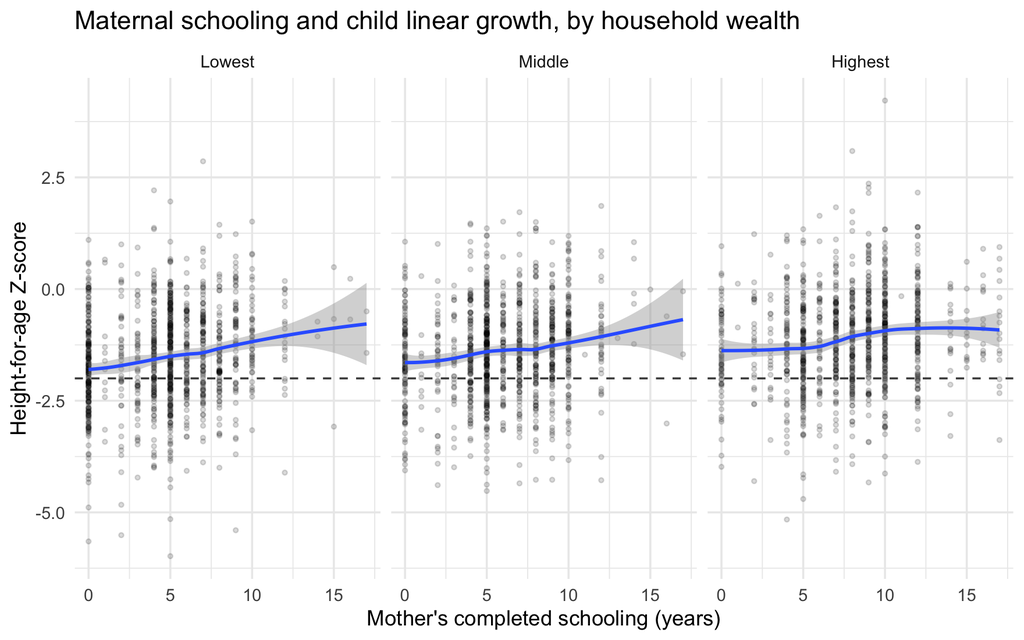

Figure 1. Height-for-age Z-score against mother’s completed schooling, by household asset tertile. Points are individual children; blue lines are loess smooths; the dashed line marks the -2 stunting threshold.

## Univariable models

| **Characteristic** | **N** | **Beta** | **95% CI** | **p-value** |
| --- | --- | --- | --- | --- |
| Growth-monitoring delivery model | 3,032 |  |  |  |
| Facility-based |  | — | — |  |
| Home-based |  | 0.05 | -0.03, 0.13 | 0.2 |
| Child's sex | 3,032 |  |  |  |
| Male |  | — | — |  |
| Female |  | 0.18 | 0.10, 0.26 | <0.001 |
| Child's age (months) | 3,032 | -0.09 | -0.12, -0.07 | <0.001 |
| Mother's age (years) | 3,032 | -0.01 | -0.02, 0.00 | 0.004 |
| Mother's schooling (years) | 3,032 | 0.06 | 0.05, 0.07 | <0.001 |
| Household asset index tertile | 3,032 |  |  |  |
| Lowest |  | — | — |  |
| Middle |  | 0.13 | 0.03, 0.22 | 0.008 |
| Highest |  | 0.41 | 0.31, 0.50 | <0.001 |
| Mother is an NGO member | 3,032 |  |  |  |
| No |  | — | — |  |
| Yes |  | -0.06 | -0.14, 0.02 | 0.15 |
| Improved toilet facility | 3,032 |  |  |  |
| No |  | — | — |  |
| Yes |  | 0.14 | -0.01, 0.30 | 0.074 |

Abbreviation: CI = Confidence Interval

Unadjusted, each additional year of maternal schooling is associated with a 0.061 (95% CI 0.050 to 0.072) higher height-for-age Z-score (p < 0.001); over the observed 0-17-year range that is close to a full standard deviation of linear growth. Children in the highest asset tertile score 0.408 (95% CI 0.312 to 0.504) Z-units above those in the lowest (p < 0.001). Height-for-age falls with age (-0.093 (95% CI -0.115 to -0.071) per month, p < 0.001) and girls score 0.182 (95% CI 0.103 to 0.260) above boys (p < 0.001). The programme variable is not significant crude: home-based GMP areas score 0.054 (95% CI -0.026 to 0.133) relative to facility-based areas (p = 0.184).

## Why adjustment is needed

The crude estimates are mutually contaminated in ways we can name. **Household asset tertile** is the clearest confounder of the maternal-schooling association: better-off households both send daughters to school for longer and feed and house their children better, so part of the crude schooling slope is really wealth. It works the other way too — the crude asset effect partly reflects the fact that wealthier households contain better-educated mothers. **Improved toilet facility** is a second one: sanitation is strongly patterned by wealth (93% coverage overall, concentrated in the upper tertiles) and poor sanitation causes the enteric infection and environmental enteropathy that stunt children, so its crude coefficient is largely borrowing wealth’s effect. **Mother’s age** is a third: older mothers in this setting have less schooling (schooling has expanded over time) and higher parity, so the crude negative age slope may simply be a schooling effect in disguise. Finally, **child age** must be in the model regardless of confounding: Z-scores in this cohort decline sharply over the 6-13-month window, so age variation adds noise to every other comparison unless it is held constant.

## Multivariable model

| **Characteristic** | **Beta** | **95% CI** | **p-value** |
| --- | --- | --- | --- |
| Growth-monitoring delivery model |  |  |  |
| Facility-based | — | — |  |
| Home-based | 0.07 | -0.01, 0.15 | 0.10 |
| Child's sex |  |  |  |
| Male | — | — |  |
| Female | 0.18 | 0.10, 0.25 | <0.001 |
| Child's age (months) | -0.10 | -0.12, -0.08 | <0.001 |
| Mother's age (years) | 0.00 | -0.01, 0.01 | 0.8 |
| Mother's schooling (years) | 0.05 | 0.04, 0.06 | <0.001 |
| Household asset index tertile |  |  |  |
| Lowest | — | — |  |
| Middle | 0.07 | -0.02, 0.16 | 0.14 |
| Highest | 0.26 | 0.16, 0.36 | <0.001 |
| Mother is an NGO member |  |  |  |
| No | — | — |  |
| Yes | -0.03 | -0.11, 0.05 | 0.5 |
| Improved toilet facility |  |  |  |
| No | — | — |  |
| Yes | -0.05 | -0.21, 0.10 | 0.5 |

Abbreviation: CI = Confidence Interval

Model fit

| Statistic | Value |
| --- | --- |
| R-squared | 0.0787 |
| Adjusted R-squared | 0.0760 |
| Residual SE | 1.067 |
| Observations | 3,032 |
| Model parameters (excl. intercept) | 9 |

The model explains 7.9% of the variance in height-for-age (adjusted R-squared 0.076) — small, but unremarkable for individual anthropometry, where most variation is genetic, gestational and idiosyncratic. Holding the other predictors constant, each extra year of maternal schooling is associated with a 0.053 (95% CI 0.041 to 0.064) higher Z-score (p < 0.001), and children in the highest asset tertile score 0.261 (95% CI 0.161 to 0.361) above the lowest (p < 0.001). Each additional month of age is associated with a -0.097 (95% CI -0.118 to -0.075) change (p < 0.001), and girls remain 0.179 (95% CI 0.102 to 0.255) above boys (p < 0.001). Adjusted for household circumstances, children in home-based GMP areas score 0.067 (95% CI -0.014 to 0.148) relative to facility-based areas (p = 0.103) — a difference compatible with no difference at all.

## Unadjusted versus adjusted

**Table 2. Unadjusted and adjusted estimates.**

| **Characteristic** | **Unadjusted** **N** | **Unadjusted** **Beta** | **Unadjusted** **95% CI** | **Unadjusted** **p-value** | **Adjusted** **Beta** | **Adjusted** **95% CI** | **Adjusted** **p-value** |
| --- | --- | --- | --- | --- | --- | --- | --- |
| Growth-monitoring delivery model | 3,032 |  |  |  |  |  |  |
| Facility-based |  | — | — |  | — | — |  |
| Home-based |  | 0.05 | -0.03, 0.13 | 0.2 | 0.07 | -0.01, 0.15 | 0.10 |
| Child's sex | 3,032 |  |  |  |  |  |  |
| Male |  | — | — |  | — | — |  |
| Female |  | 0.18 | 0.10, 0.26 | <0.001 | 0.18 | 0.10, 0.25 | <0.001 |
| Child's age (months) | 3,032 | -0.09 | -0.12, -0.07 | <0.001 | -0.10 | -0.12, -0.08 | <0.001 |
| Mother's age (years) | 3,032 | -0.01 | -0.02, 0.00 | 0.004 | 0.00 | -0.01, 0.01 | 0.8 |
| Mother's schooling (years) | 3,032 | 0.06 | 0.05, 0.07 | <0.001 | 0.05 | 0.04, 0.06 | <0.001 |
| Household asset index tertile | 3,032 |  |  |  |  |  |  |
| Lowest |  | — | — |  | — | — |  |
| Middle |  | 0.13 | 0.03, 0.22 | 0.008 | 0.07 | -0.02, 0.16 | 0.14 |
| Highest |  | 0.41 | 0.31, 0.50 | <0.001 | 0.26 | 0.16, 0.36 | <0.001 |
| Mother is an NGO member | 3,032 |  |  |  |  |  |  |
| No |  | — | — |  | — | — |  |
| Yes |  | -0.06 | -0.14, 0.02 | 0.15 | -0.03 | -0.11, 0.05 | 0.5 |
| Improved toilet facility | 3,032 |  |  |  |  |  |  |
| No |  | — | — |  | — | — |  |
| Yes |  | 0.14 | -0.01, 0.30 | 0.074 | -0.05 | -0.21, 0.10 | 0.5 |

Abbreviation: CI = Confidence Interval

Three patterns stand out. First, **household assets moved substantially toward the null**: the highest-versus-lowest tertile difference shrank from 0.408 (95% CI 0.312 to 0.504) to 0.261 (95% CI 0.161 to 0.361), roughly a 36% attenuation, and the middle-versus-lowest contrast lost significance entirely (p = 0.008 crude, p = 0.144 adjusted). Maternal schooling attenuated in the same direction but less (0.061 (95% CI 0.050 to 0.072) to 0.053 (95% CI 0.041 to 0.064)). Each was confounding the other, as anticipated. Second, two predictors **crossed the significance line**: mother’s age went from -0.010 (95% CI -0.017 to -0.003) (p = 0.004) to essentially zero, 0.001 (95% CI -0.006 to 0.008) (p = 0.777), so the crude maternal-age association was entirely schooling and wealth; and improved toilet reversed sign, from 0.145 (95% CI -0.014 to 0.303) (p = 0.074) to -0.054 (95% CI -0.211 to 0.103) (p = 0.500) — the crude sanitation “effect” was a wealth proxy. Third, **child sex and child age barely moved at all** (sex 0.182 (95% CI 0.103 to 0.260) to 0.179 (95% CI 0.102 to 0.255)), which is exactly what should happen: sex is randomly assigned by biology and age was balanced by the sampling frame, so neither is confounded by household characteristics. The delivery-model coefficient also barely moved and stayed non-significant, consistent with the matched-pair design having balanced households across the two arms. These are confounding effects, not collinearity artefacts: all variance inflation factors are below 1.3.

## Diagnostics

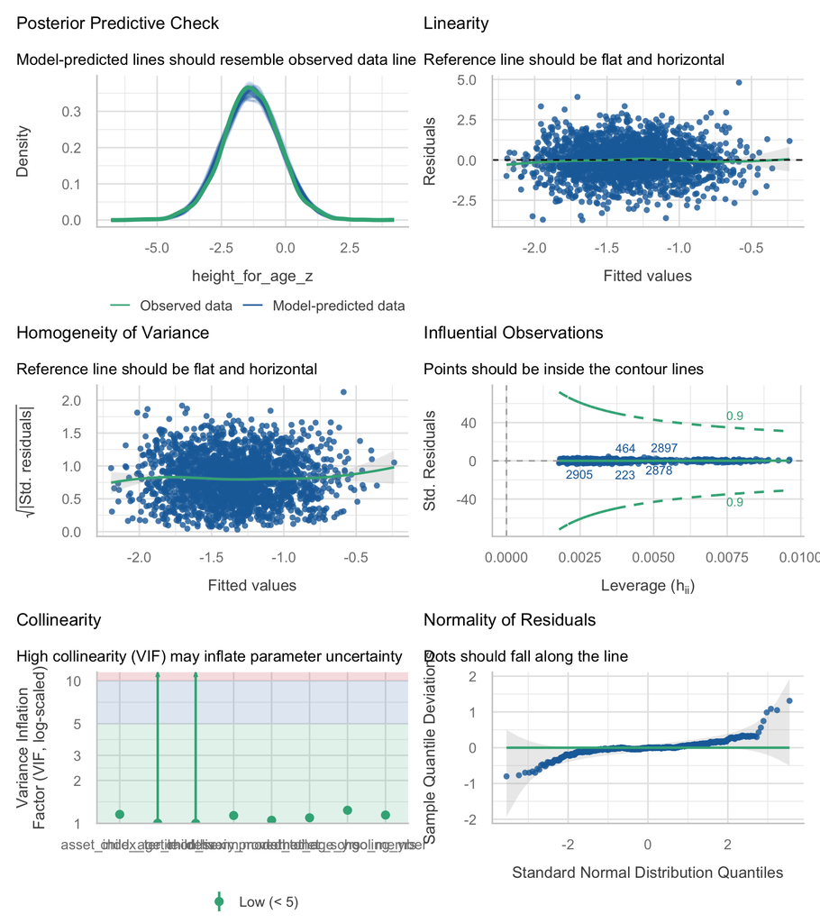

Variance inflation factors

| Term | VIF |
| --- | --- |
| delivery_model | 1.14 |
| child_sex | 1.00 |
| child_age_months | 1.00 |
| mother_age_yrs | 1.10 |
| mother_schooling_yrs | 1.24 |
| asset_index_tertile | 1.16 |
| ngo_member | 1.14 |
| improved_toilet | 1.05 |

The *posterior predictive check* and *linearity* panels look acceptable: fitted values track observed values without curvature, and the residual smooth is essentially flat, so a straight-line term for age and for schooling is defensible. *Homogeneity of variance* is satisfactory — the spread of residuals is constant across the fitted range. The *normality of residuals* Q-Q plot shows mild departure in both tails, driven by a handful of extremely short children (Z below -4) and a few implausibly tall ones (Z above +4); with n over 3,000 the central limit theorem makes the coefficient standard errors robust to this, and no observation exceeds the Cook’s-distance contours in the *influential observations* panel. *Collinearity* is a non-issue as specified, with all VIFs under 1.3 — but only because `sub_district` was deliberately excluded; including it drives the delivery-model VIF to about 96.

# Discussion

Among rural Bangladeshi infants aged 6-13 months, linear growth is patterned mainly by socio-economic position, not by how growth monitoring was delivered. Maternal schooling and household assets remain independently associated with height-for-age after mutual adjustment, while sanitation and maternal age turn out to have had no independent association once wealth and schooling are accounted for. Practically, this says that a service-delivery reorganisation of GMP is not, by itself, visible in children’s linear growth in this cross-section, whereas the household’s education and material circumstances are.

**Limitations.**

*The outcome distribution is truncated by design.* The source paper states that children with severe stunting, wasting or underweight were excluded on ethical grounds so that they could be referred for care. The shipped file nonetheless contains 202 children with height-for-age below -3, so the exclusion was either incomplete or applied on a different criterion. Either way, the lower tail of this outcome has been interfered with: the observed 26.6% stunting prevalence understates the true burden, and any coefficient describing how a predictor shifts the low end of the HAZ distribution is attenuated. This is a genuine, documented contradiction in the source, not a data-cleaning artefact we could fix.

*Clustering cannot be modelled.* The exposure of interest, delivery model, is an **area-level** variable assigned to whole upazilas — six of them — and the survey sampled 60 community-clinic catchment areas as matched pairs. Children within a catchment share the same fieldworker, clinic, market and water supply, so their outcomes are correlated. The file contains no clinic or cluster identifier, so this cannot be handled with random effects or cluster-robust standard errors. The confidence interval on `delivery_model` is therefore too narrow, possibly by a large factor, and its p-value should not be taken at face value. `sub_district` is not a usable substitute cluster variable because it is collinear with the exposure.

*Age definition is inconsistent in the source.* The paper’s abstract describes children “under one year”, its methods section says 6-23 months, and the data actually run 6.0 to 13.0 months. We describe the observed range; readers should not assume the analysis covers the whole 6-23-month window. The narrow 7-month age span also limits how much of the well-known age-related HAZ decline is visible.

*Design and residual confounding.* This is a cross-sectional survey, so all estimates are associations, not effects; birth weight, gestational age, maternal height, breastfeeding history, diet quality and recent illness are all absent and all cause stunting. Adjusted R-squared of 0.076 makes clear that most of the variation is unexplained.

*Sparse and dropped variables.* `mother_occupation` and `religion_muslim` were excluded as near-constant; conclusions about occupation or religion cannot be drawn from these data at all.

**Future work.** A cluster-identified longitudinal follow-up, with birth weight and feeding history recorded and without the severe-malnutrition exclusion, would be needed to say anything causal about GMP delivery and linear growth.

# Feasibility notes

*Not part of a student report.*

**Verdict: usable, and the best of the three continuous outcomes.** This is a workable Purpose 3 question with a clean set of eight predictors, a genuinely interesting adjustment story and no fitting problems.

What a student will hit:

1. **`delivery_model` versus `sub_district` is a trap that must be flagged in the brief.** The two are 99.7% identical (8 discordant records out of 3038). A student who dumps every column into `lm()` gets VIFs around 96-103, a sign-flipped delivery coefficient (-0.79 instead of +0.07) and a nine-fold inflated standard error, and will happily report it. The choice must be made and justified before modelling.
2. **`stunted` must never be used as a predictor here.** It is defined exactly as `height_for_age_z < -2` — it reproduces the outcome deterministically. The same applies in reverse in the `stunted.Rmd` companion analysis. Likewise, using `weight_for_age_z` to predict `height_for_age_z` is a bad idea: the two share the same height measurement and the same child, so the model becomes an arithmetic identity check rather than an epidemiological question.
3. **The adjustment story is real, which is the main reason to prefer this outcome.** Assets attenuate ~36%, maternal age goes from significant to null, and improved toilet flips sign. There is plenty for the “what changed after adjustment” section to bite on. Contrast this with `stunted`, where the movement is much more muted.
4. **Near-constant predictors.** Sensitivity fit adding them back, for reference:

Near-constant predictors, added back

n = 77 non-housewives, 66 non-Muslim households

| term | estimate | conf.low | conf.high | p.value |
| --- | --- | --- | --- | --- |
| mother_occupationOther | -0.215 | -0.463 | 0.032 | 0.088 |
| religion_muslimMuslim | -0.293 | -0.554 | -0.033 | 0.027 |

The intervals are wide and the “Muslim” coefficient is large and negative on the strength of 66 comparison households. Nothing here should be interpreted; it is included only to show why both were dropped.

5. **Fit is low but honest.** R-squared of 0.079 will alarm students who expect a “good” model. Worth pre-empting in the brief: for individual-level anthropometry this is normal, and the assignment is about which predictors survive adjustment, not about prediction.
6. **Residual tails.** A handful of Z-scores beyond |4| (biologically implausible and normally flagged by WHO as out of plausible range) produce visible Q-Q departure. They are not influential, so we left them in, but a student may reasonably want to run a sensitivity analysis excluding them.